# Read information from Google Sheet

https://www.twilio.com/blog/2017/02/an-easy-way-to-read-and-write-to-a-google-spreadsheet-in-python.html

https://towardsdatascience.com/accessing-google-spreadsheet-data-using-python-90a5bc214fd2

## Google Drive API and Service Accounts

To programmatically access your spreadsheet, you’ll need to create a service account and OAuth2 credentials from the Google API Console. https://console.developers.google.com/

If you’ve been traumatized by OAuth2 development before, don’t worry; service accounts are way easier to use.

> 1.Go to the Google APIs Console.

> 2.Create a new project.

> 3.Click Enable API. Search for and enable the Google Drive API.

> 4.Create credentials for a Web Server to access Application Data.

> 5.Name the service account and grant it a Project Role of Editor.

> 6.Download the JSON file.

> 7.Copy the JSON file to your code directory and rename it to client_secret.json

There is one last required step to authorize your app, and it’s easy to miss!

Find the client_email inside client_secret.json. Back in your spreadsheet, click the Share button in the top right, and paste the client email into the People field to give it edit rights. Hit Send.

If you skip this step, you’ll get a gspread.exceptions.SpreadsheetNotFound error when you try to access the spreadsheet from Python.

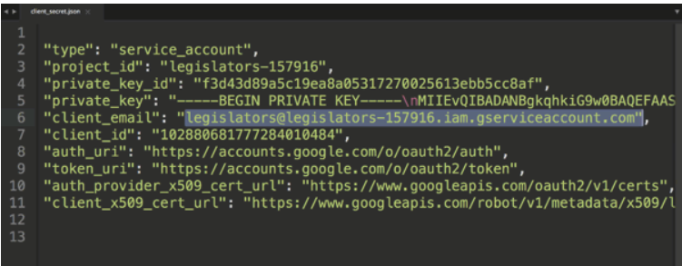

In the SpreadSheet share autorization to the "client_email": "solicitacoes@solicitacoes.iam.gserviceaccount.com", the you have in the JSON file.

## Read Data from a Spreadsheet with Python

With credentials in place (you did copy them to your code directory, right?) accessing a Google Spreadsheet in Python requires just two packages:

> > oauth2client – to authorize with the Google Drive API using OAuth 2.0

> > gspread – to interact with Google Spreadsheets

Install these packages with:

pip install gspread oauth2client

```python
import gspread
from oauth2client.service_account import ServiceAccountCredentials
import pprint


# use creds to create a client to interact with the Google Drive API
scope = ['https://spreadsheets.google.com/feeds', 'https://www.googleapis.com/auth/drive']

creds = ServiceAccountCredentials.from_json_keyfile_name('Client_My_Drive_API_Secret.json', scope)
client = gspread.authorize(creds)

# Find a workbook by name and open the first sheet
# Make sure you use the right name here.
sheet = client.open("TESTE_ROB").sheet1

# Extract and print all of the values
list_of_records = sheet.get_all_records()
#print(list_of_records)

pp = pprint.PrettyPrinter()
records = sheet.get_all_records()
pp.pprint(records)
```

```
[{'Nome': 'Manuel', 'data': '01-01-2020', 'email': 'mrobalinho@gmail.com'},
 {'Nome': 'Silva', 'data': '30-01-2020', 'email': 'robalinho.manuel@gmail.com'},
 {'Nome': 'Robalinho',
  'data': '30-04-2020',
  'email': 'manuel.robalinho@hotmail.com'}]
```

# Another process

## Using a Spreadsheet published on WEB csv format

https://stackoverflow.com/questions/24063629/loading-a-generic-google-spreadsheet-in-pandas

```python
# In google sheet click file>publish to web. Then select what do you need to publish
# and select export format .csv. You'll have the link something like:
# https://docs.google.com/spreadsheets/d/e/2PACX-1vR_ATduoaxlkUYpvk3RcfFJZst0_ik0bBOAFrANK2im3LROO2Owyd07jokgpzHs3KOPJX9CG0lC6Hk4/pub?gid=0&single=true&output=csv

import pandas as pd

pathtoCsv = r'https://docs.google.com/spreadsheets/d/e/2PACX-1vR_ATduoaxlkUYpvk3RcfFJZst0_ik0bBOAFrANK2im3LROO2Owyd07jokgpzHs3KOPJX9CG0lC6Hk4/pub?gid=0&single=true&output=csv'
dev = pd.read_csv(pathtoCsv)
print(dev)
```

```
        Nome                         email data_admissao
0     Manuel          mrobalinho@gmail.com    01-01-2020
1      Silva    robalinho.manuel@gmail.com    30-01-2020
2  Robalinho  manuel.robalinho@hotmail.com    30-04-2020
```

```python
dev.head()
```

|  | Nome | email | data_admissao |
| --- | --- | --- | --- |
| 0 | Manuel | mrobalinho@gmail.com | 01-01-2020 |
| 1 | Silva | robalinho.manuel@gmail.com | 30-01-2020 |
| 2 | Robalinho | manuel.robalinho@hotmail.com | 30-04-2020 |

## Using a Spreadsheet from a Google Form

```python
# In google sheet click file >publish to web. Then select what do you need to publish
# and select export format .csv. You'll have the link something like:
# https://docs.google.com/spreadsheets/d/e/2PACX-1vTCzhHz4OXrL1LfkUVEeGFO4bFwXzdati4Wlx8XA-rjcJsaI4lF9TA8SQM12RBdMFDZazk6Y9YKVe6x/pub?gid=1308699123&single=true&output=csv

# That case i used a Spreadsheet created from Google Forms using the same technique
import pandas as pd

pathtoCsv = r'https://docs.google.com/spreadsheets/d/e/2PACX-1vTCzhHz4OXrL1LfkUVEeGFO4bFwXzdati4Wlx8XA-rjcJsaI4lF9TA8SQM12RBdMFDZazk6Y9YKVe6x/pub?gid=1308699123&single=true&output=csv'
dev = pd.read_csv(pathtoCsv)
dev.head(20)
```

|  | Carimbo de data/hora | Email | Centro Custo | Conta | Valor | Motivo |
| --- | --- | --- | --- | --- | --- | --- |
| 0 | 2020/06/14 16:26:14 | manuel.robalinho@gmail.com | 320111104 | 4110101001 | 5000 | NaN |
| 1 | 2020/06/14 16:28:47 | robalinho.manuel@gmail.com | 4101111004 | 4110101002 | 10000 | NaN |
| 2 | 2020/06/14 16:30:02 | manuel.robalinho@hotmail.com | 410127305 | 4110101003 | 100000 | NaN |
| 3 | 2020/06/14 16:33:49 | manuel.robalinho@gmail.com | 110401007 | 4110101004 | 44000 | Falta orçamento |
| 4 | 2020/06/14 17:57:47 | manuel.robalinho@acocearense.com.br | 320127305 | 4110101006 | 45000 | Novo Pedido compra |
| 5 | 2020/06/14 19:12:01 | jonys@gmail.com | 310141002 | 4110101005 | 4500 | Um teste |
| 6 | 2020/06/14 19:26:57 | Luis@gmail.com | 310127303 | 4110101006 | 44000 | TESTE Manuel |
| 7 | 2020/06/14 19:30:50 | pedro@gmail.com | 410122303 | 4110101005 | 37000 | Teste Pedro |
| 8 | 2020/06/14 20:11:36 | nuno@gmail.com | 310127405 | 4110101006 | 27000 | Pedido compra ABCD |